# Quantitative Trading Strategy Project

## Introduction

This project focuses on designing a momentum-based short-selling strategy around **index rebalancing events**, particularly targeting **one-off events**. The strategy is built using quantitative analysis, technical indicators, and strict liquidity constraints to capture price distortions caused by index additions. Risk management is integrated through a **SPY hedge** to mitigate market-wide movements. The main technical indicators used in this strategy include **RSI**, **MACD**, **Bollinger Bands**, and **ATR**, which are well-suited for identifying overbought conditions and momentum shifts based on my personal equity trading experience.

## Data Extraction, Cleaning, and Liquidity Filtering

### Initial Data Inspection and Cleaning

I began by loading the dataset and addressing missing values using `pandas` and defining appropriate `na_values`. Initial attempts to fill missing fields (like `$MM to Trade` and `Shares to Trade`) were later abandoned as most stocks with missing data were delisted or invalid. For conciseness, I removed these tickers and cleaned the data thoroughly.

Special characters in the **Ticker** column (e.g., `*`, `-W`, `-V`) were stripped, and spaces were removed. The validity of each ticker was confirmed by fetching historical data from Yahoo Finance (`yfinance`), ensuring that only tickers with valid data were retained.

### Event Classification: One-off vs. Scheduled Events

The dataset was classified into:

- **One-off Events**: Events occurring outside regularly scheduled rebalancing months.
- **Scheduled Events**: Events occurring in March, June, September, and December.

This allowed for filtering based on event type, with a focus on **one-off events** for strategy development.

### Liquidity Constraints

To minimize market impact, I imposed a **liquidity constraint** based on the 20-day average trading volume, ensuring that no position size exceeded 1% of a stock’s average volume, with a **minimum threshold of 50,000 shares**. This constraint was designed to ensure smooth trade execution without moving the market.

1. **Mathematical Justification**: In managing a 5,000,000 portfolio, I allocate 76% of the total capital to my aggressive short strategy, splitting this evenly across four stocks, meaning each stock receives 19% of the portfolio. The remaining 24% is allocated to a SPY hedge.To avoid creating market distortions while deploying substantial capital, I ensure that my strategy does not exceed 1% of the 20-day average trading volume for each stock. Given my capital and liquidity constraints, this balance is critical in ensuring smooth trade execution without becoming a "whale" in the market.

For context, the maximum position I could theoretically take would be 50,000 shares of a stock priced at 100 dollars. However, given that only 76% of my capital is allocated to the aggressive strategy, my total allocation per stock is limited to 19% of 5,000,000 or 950,000 per stock.

This calculation allows me to trade substantial volumes without impacting the market. For instance:

If a stock's price is 100 dollars, I can purchase 9,500 shares (950,000 / 100), which is well below the typical 50,000-share daily average.

Even if a stock’s price were lower (e.g., 50 per share), my 950,000 allocation would enable me to purchase 19,000 shares, which would still be only a fraction of the daily trading volume (about 38% of a typical 50,000-share daily average).

By adhering to these liquidity constraints, I can confidently deploy large sums of capital in stocks without exceeding 1% of the daily trading volume. This ensures that my trades don’t move the market or attract unwanted attention from larger players or algorithms, allowing me to act efficiently without becoming a "whale" and disrupting normal market behavior.

1. **Market Dynamics**: In high-frequency environments, large trades can attract unwanted attention from algorithms. The liquidity constraint ensures minimal market disruption.

### Data Extraction for Trading Strategy

After filtering for liquidity, I extracted 100 days of **Open**, **Close**, **High**, **Low**, and **Volume** data starting from the event announcement date. This data formed the basis for technical analysis and signal generation.

## Creation of Baseline Analysis Techniques: Leveraging Technical Analysis from Personal Equity Trading Experience

### Intraday vs. Daily Data

Where available, I utilized **intraday data** for signal generation, as index rebalancing events often lead to short-term price distortions. For stocks without intraday data, I relied on **daily data**. Intraday data provides more precise entries and exits, especially in volatile conditions.

### Strategy Insights from Personal Trading Experience

Drawing from my trading experience, I often observed retail traders “**holding the bag**”—continuing to hold stocks after their fair value had been distorted by market events. This strategy exploits such distortions by shorting **one-off event** stocks after their prices temporarily rise due to index additions.

### Volume Dynamics in One-off Events

Index additions often trigger a **spike in volume**. This temporary volume increase allows my strategy to capitalize on price distortions. The strategy benefits from the natural price reversion that occurs once the initial excitement surrounding index inclusion fades.

### Trading Constraints and Strategy Adjustments

Given the restriction against **intraday buying and selling**, I adopted a conservative approach—focusing on **shorting overbought stocks** rather than long positions. I named this strategy **"Mr. Bear"**, as it exploits overbought conditions to capture price reversals. The strategy is designed to re-enter after stop-losses if overbought conditions persist, offering flexibility.

### Simplicity over Complexity

Initially, I considered more complex approaches such as **pairs trading** and **cointegration**. However, I chose to focus on a simpler, momentum-based approach first, which yielded strong results. Simplicity often proves highly effective when backed by a deep understanding of market dynamics.

Although I did not implement predictive models in this strategy, I would explore more complex techniques (e.g., **regularized regression with technical indicators** and **machine learning models**) to predict future events or test the strategy on unseen data in a real-world environment. If you're interested in my predictive models using **ML algorithms** and **Statistical Computing techniques**, feel free to check out my **Quantitative Research Project** on my GitHub.

## Statistical Assumptions and Validation

In this strategy, I assumed that **price reversion** would naturally occur after index inclusion due to overbought conditions. This assumption relies on **mean reversion** theory, which posits that prices will revert to their average over time. While my focus was on one-off events, further testing would involve ensuring the strategy's robustness by testing it on:

- **Different market conditions**: How does the strategy perform during a bull market or a bear market?
- **Cross-validation**: Implementing walk-forward optimization techniques to ensure that the parameters (e.g., RSI thresholds) aren't overfitted to the historical data.
- **Out-of-sample testing**: Applying the strategy to unseen data to validate its predictive power.

### Robustness and Risk Management

Future iterations would include **robustness checks** by adding:

- **Monte Carlo simulations**: To evaluate the strategy's performance under different random market scenarios.
- **Backtesting on additional indices or asset classes**: To see if the strategy generalizes well beyond the S&P 500 index.
- **Hedging enhancements**: Exploring dynamic hedging strategies to adjust the SPY hedge based on market conditions.

## Strategy Workflow:

1. **Data Cleaning**:
   - Handled missing values and cleaned ticker symbols.
   - Validated tickers using `yfinance`.
2. **Liquidity Filtering**:
   - Set a minimum liquidity threshold of 50,000 shares, representing 1% of the 20-day average trading volume.
3. **Data Extraction**:
   - Extracted 100 days of Open, Close, High, Low, and Volume data for **One-off** and **Scheduled Events**.
4. **Technical Indicators**:
   - **RSI** identified overbought conditions for short entries.
   - **Bollinger Bands** and **MACD** confirmed momentum, while **ATR** informed stop-loss levels and presence of volatility.
5. **Strategy Execution**:
   - **Signal Generation**: Short positions triggered by overbought conditions and excessive price moves.
   - **Exit Strategy**: Exited below the lower Bollinger Band or at 20% profit; stop-losses were triggered by continued momentum.
6. **Portfolio Allocation**:
   - Allocated 19% of the portfolio to each liquid stock and reserved 24% for the SPY hedge.
   - The Mathematical reasoning for this is that I wanted my aggressive bearish strategy to dominate, but also consider instances where I may be getting stopped out repeatedly and in these instances, I am able to reduce the losses or offset them with the SPY hedge.
7. **SPY Hedge**:
   - Used a long SPY position to hedge against market risk and mitigate losses during uptrends.
8. **Transaction and Overnight Costs**:
   - Included transaction costs ($0.01 per share) and overnight holding costs (based on the **Fed Funds Rate**).
9. **Performance Evaluation**:
   - Assessed profit and loss for each stock, calculated cumulative returns, and factored in all costs.

## Key Takeaways:

1. **Liquidity Constraints**: Ensured smooth execution and minimal market impact.
2. **Effective Use of Indicators**: The combination of RSI and Bollinger Bands effectively captured overbought conditions for short entries.
3. **SPY Hedge**: Provided protection during market-wide uptrends, offsetting potential short strategy losses.
4. **Cost Management**: Factored in transaction and overnight costs for accurate profit calculations.
5. **Simplicity Wins**: A straightforward strategy focusing on technical analysis proved highly effective. Future iterations could include more complex models, but simplicity often works well with a strong understanding of the market.

## Conclusion:

This project demonstrates how quantitative strategies can exploit price distortions caused by index rebalancing events. By focusing on **One-off Events** and using technical indicators, I developed a robust short-selling strategy with integrated risk management. While this approach was backward-looking and only applied to historical data, future improvements could involve using predictive models, regularized regression, or machine learning techniques to forecast events. Simplicity in this strategy yielded effective results, but further complexity can be explored if necessary. Check out my **Quantitative Research Project** on my GitHub for more complex statistical analysis.

### Code for Data Extraction, Exploration and Cleaning

```python
import pandas as pd
import yfinance as yf
import matplotlib.pyplot as plt
import seaborn as sns
from fredapi import Fred
import numpy as np

# Step 1: Load the Data
na_values = ["Null", "NA", "Nan", "NaN", "-", "", "N/A"]
file_path = "/Users/aidanashrafi/Downloads/Index_Add_Event_Data.xlsx"
dfs = pd.read_excel(file_path, sheet_name=None, na_values=na_values)

# Access the main data sheet
data_df = dfs.get("Data")

# Step 2: Drop rows with any missing values and clean the ticker column
def clean_ticker_column(df):
    df['Ticker'] = df['Ticker'].str.replace('*', '', regex=False)
    df['Ticker'] = df['Ticker'].str.replace('-W', '', regex=False)
    df['Ticker'] = df['Ticker'].str.replace('-V', '', regex=False)
    df['Ticker'] = df['Ticker'].str.replace('-', '', regex=False)
    df['Ticker'] = df['Ticker'].apply(lambda x: x[:-2] if x.endswith('US') else x)
    df['Ticker'] = df['Ticker'].str.strip().str[:4]  # Strip spaces and limit to 4 characters
    return df

data_df_cleaned = clean_ticker_column(data_df.dropna().copy())

# Step 3: Validate tickers by checking if they have valid data in YFinance
def check_valid_ticker(ticker):
    stock = yf.Ticker(ticker)
    hist = stock.history(period='1mo')
    return not hist.empty

# Filter for valid tickers
data_df_cleaned['Valid_Ticker'] = data_df_cleaned['Ticker'].apply(check_valid_ticker)
data_df_cleaned = data_df_cleaned[data_df_cleaned['Valid_Ticker']].drop(columns=['Valid_Ticker']).copy()

# Step 4: Remove scheduled events (March, June, September, December)
scheduled_months = [3, 6, 9, 12]
data_df_cleaned['Month'] = pd.to_datetime(data_df_cleaned['Announced']).dt.month
one_off_filtered_df = data_df_cleaned[~data_df_cleaned['Month'].isin(scheduled_months)].copy()
scheduled_df = data_df_cleaned[data_df_cleaned['Month'].isin(scheduled_months)].copy()  # Define `scheduled_df`

# Step 5: Calculate 20-day average volume for one-off and scheduled events
def get_20_day_avg_volume(ticker, announcement_date):
    stock = yf.Ticker(ticker)
    hist = stock.history(start=announcement_date - pd.Timedelta(days=40), end=announcement_date)
    return hist['Volume'].rolling(window=20).mean().iloc[-1] if not hist.empty else None

one_off_filtered_df['20_Day_Avg_Volume'] = one_off_filtered_df.apply(
    lambda row: get_20_day_avg_volume(row['Ticker'], row['Announced']), axis=1)
one_off_filtered_df['Liquidity_Constrained_Position_Size'] = one_off_filtered_df['20_Day_Avg_Volume'].apply(
    lambda avg_volume: 0.01 * avg_volume if avg_volume else 0)

scheduled_df['20_Day_Avg_Volume'] = scheduled_df.apply(
    lambda row: get_20_day_avg_volume(row['Ticker'], row['Announced']), axis=1)
scheduled_df['Liquidity_Constrained_Position_Size'] = scheduled_df['20_Day_Avg_Volume'].apply(
    lambda avg_volume: 0.01 * avg_volume if avg_volume else 0)

# Step 6: Filter out illiquid stocks for both one-off and scheduled events
position_threshold = 50000

# For one-off events
one_off_liquid_stocks_df = one_off_filtered_df[one_off_filtered_df['Liquidity_Constrained_Position_Size'] >= position_threshold].copy()

# For scheduled events
scheduled_liquid_stocks_df = scheduled_df[scheduled_df['Liquidity_Constrained_Position_Size'] >= position_threshold].copy()

# Combine liquid stocks from both one-off and scheduled events
liquid_stocks_df = pd.concat([one_off_liquid_stocks_df, scheduled_liquid_stocks_df]).copy()
print("\n Number of Liquid Stocks: ", len(liquid_stocks_df))
print("\n Number of Liquid Stocks with One-Off Events: ", len(one_off_liquid_stocks_df))
# Step 7: Extract Open and Close Prices with column labels formatted with '_Close' and '_Open'
def extract_prices(tickers, start_dates, days=100):
    close_prices, open_prices, combined_prices = [], [], []
    for ticker, start_date in zip(tickers, start_dates):
        stock = yf.Ticker(ticker)
        hist = stock.history(start=start_date, end=start_date + pd.Timedelta(days=days))
        if not hist.empty:
            close_series = hist['Close'].reset_index(drop=True).rename(f"{ticker}_Close")
            open_series = hist['Open'].reset_index(drop=True).rename(f"{ticker}_Open")
            close_prices.append(close_series)
            open_prices.append(open_series)

            # Combined open and close prices
            combined_series = pd.DataFrame({
                f"{ticker}_Open": open_series,
                f"{ticker}_Close": close_series
            })
            combined_prices.append(combined_series)

    close_prices_df = pd.concat(close_prices, axis=1) if close_prices else pd.DataFrame()
    open_prices_df = pd.concat(open_prices, axis=1) if open_prices else pd.DataFrame()
    combined_prices_df = pd.concat(combined_prices, axis=1) if combined_prices else pd.DataFrame()

    return close_prices_df, open_prices_df, combined_prices_df

# Extract prices for both one-off and scheduled events
tickers_one_off = one_off_liquid_stocks_df['Ticker'].tolist()
start_dates_one_off = one_off_liquid_stocks_df['Announced'].tolist()
close_prices_one_off, open_prices_one_off, combined_prices_one_off = extract_prices(tickers_one_off, start_dates_one_off)

tickers_scheduled = scheduled_liquid_stocks_df['Ticker'].tolist()
start_dates_scheduled = scheduled_liquid_stocks_df['Announced'].tolist()
close_prices_scheduled, open_prices_scheduled, combined_prices_scheduled = extract_prices(tickers_scheduled, start_dates_scheduled)
```

```
RUSH: No price data found, symbol may be delisted (period=1mo)
PACW: No data found, symbol may be delisted
NEX: No data found, symbol may be delisted
FBHS: No data found, symbol may be delisted
CBTX: No data found, symbol may be delisted
AVID: No data found, symbol may be delisted
HTA: No data found, symbol may be delisted
```

```
 Number of Liquid Stocks:  9

 Number of Liquid Stocks with One-Off Events:  4
```

```python
# Check to make sure I have what I want
liquid_stocks_df
```

|  | Announced | Trade Date | Index Change | Ticker | Action | Last Px | Sector | Shs to Trade | $MM to Trade | ADV to Trade | Month | 20_Day_Avg_Volume | Liquidity_Constrained_Position_Size |
| --- | --- | --- | --- | --- | --- | --- | --- | --- | --- | --- | --- | --- | --- |
| 1 | 2024-07-23 | 2024-07-25 | S&P 400 | AVTR | Add | 21.17 | Healthcare | 74808923.0 | 1583.7 | 10.48 | 7 | 6089215.0 | 60892.15 |
| 8 | 2024-05-03 | 2024-05-07 | S&P 600 | MARA | Add | 17.52 | Info Tech | 29030300.0 | 508.6 | 0.67 | 5 | 40887040.0 | 408870.40 |
| 42 | 2023-08-21 | 2023-08-24 | S&P 500 | KVUE | Add | 22.90 | Cons Stap | 300389422.0 | 6878.9 | 8.81 | 8 | 38821500.0 | 388215.00 |
| 119 | 2022-10-17 | 2022-10-19 | S&P 400 | AR | Add | 33.93 | Energy | 30910807.0 | 1048.8 | 4.68 | 10 | 6855325.0 | 68553.25 |
| 15 | 2024-03-26 | 2024-03-28 | S&P 400 | ROIV | Add | 10.08 | Healthcare | 37158708.0 | 374.6 | 7.20 | 3 | 5261085.0 | 52610.85 |
| 64 | 2023-06-05 | 2023-06-16 | S&P 500 | PANW | Add | 217.24 | Information Technology | 44093704.0 | 9578.9 | 9.22 | 6 | 5465865.0 | 54658.65 |
| 106 | 2022-12-19 | 2022-12-21 | S&P 400 | SMCI | Add | 78.29 | Info Tech | 5054602.0 | 395.7 | 5.50 | 12 | 9114800.0 | 91148.00 |
| 125 | 2022-09-23 | 2022-09-30 | S&P 500 | PCG | Add | 12.61 | Utilities | 279658925.0 | 3526.5 | 19.08 | 9 | 17081740.0 | 170817.40 |
| 155 | 2022-06-03 | 2022-06-07 | S&P 500 | VICI | Add | 32.45 | Real Estate | 146440651.0 | 4752.0 | 9.06 | 6 | 10401865.0 | 104018.65 |

### Simple Correlation Analysis

```python
# Generalized Correlation Analysis Function
def calculate_correlation(df, close_prices_df, event_type="Event"):
    # Get the tickers for the event type
    desired_tickers = df['Ticker'].tolist()

    # Append '_Close' to each ticker to match the columns in `close_prices_df`
    desired_columns = [ticker + '_Close' for ticker in desired_tickers]

    # Filter `close_prices_df` to only include these tickers
    filtered_close_prices_df = close_prices_df[desired_columns]

    # Calculate the correlation matrix
    correlation_matrix = filtered_close_prices_df.corr()

    # Visualize the correlation matrix using a heatmap
    plt.figure(figsize=(12, 10))
    sns.heatmap(correlation_matrix, annot=False, cmap="coolwarm", xticklabels=desired_tickers, yticklabels=desired_tickers)
    plt.title(f"Correlation Matrix Heatmap for {event_type}")
    plt.xticks(rotation=90)
    plt.yticks(rotation=0)
    plt.show()

    # Print the correlation matrix
    print(f"Full Correlation Matrix for {event_type}:")
    print(correlation_matrix)

    return correlation_matrix
```

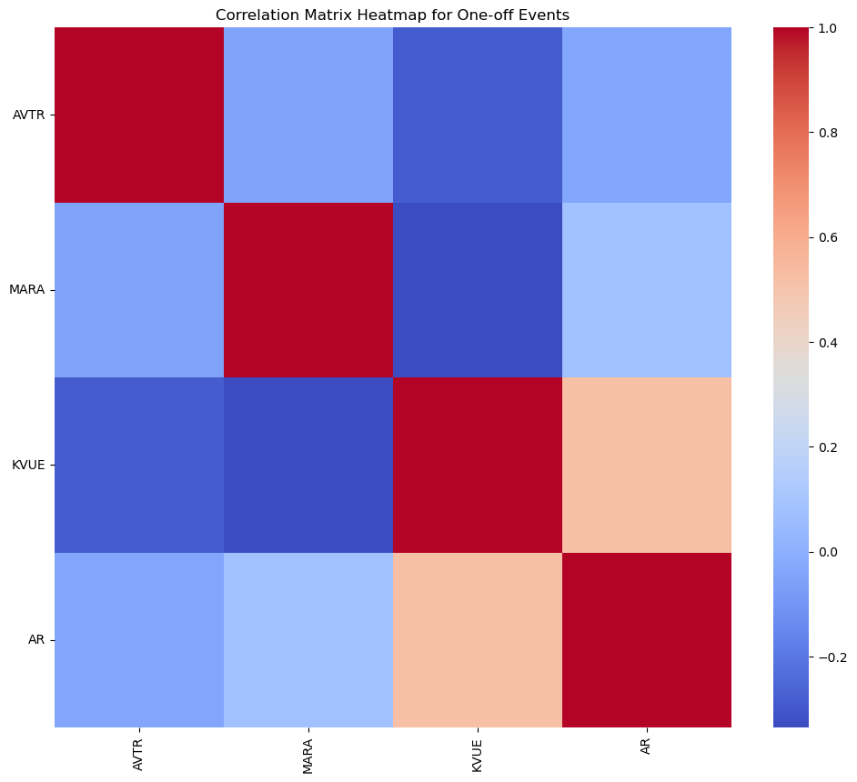

```
Full Correlation Matrix for One-off Events:
            AVTR_Close  MARA_Close  KVUE_Close  AR_Close
AVTR_Close    1.000000   -0.053166   -0.284631 -0.038350
MARA_Close   -0.053166    1.000000   -0.335444  0.077621
KVUE_Close   -0.284631   -0.335444    1.000000  0.521008
AR_Close     -0.038350    0.077621    0.521008  1.000000
```

```python
# Call the generalized correlation function for one-off events
one_off_correlation_matrix = calculate_correlation(one_off_liquid_stocks_df, close_prices_one_off, event_type="One-off Events")
```

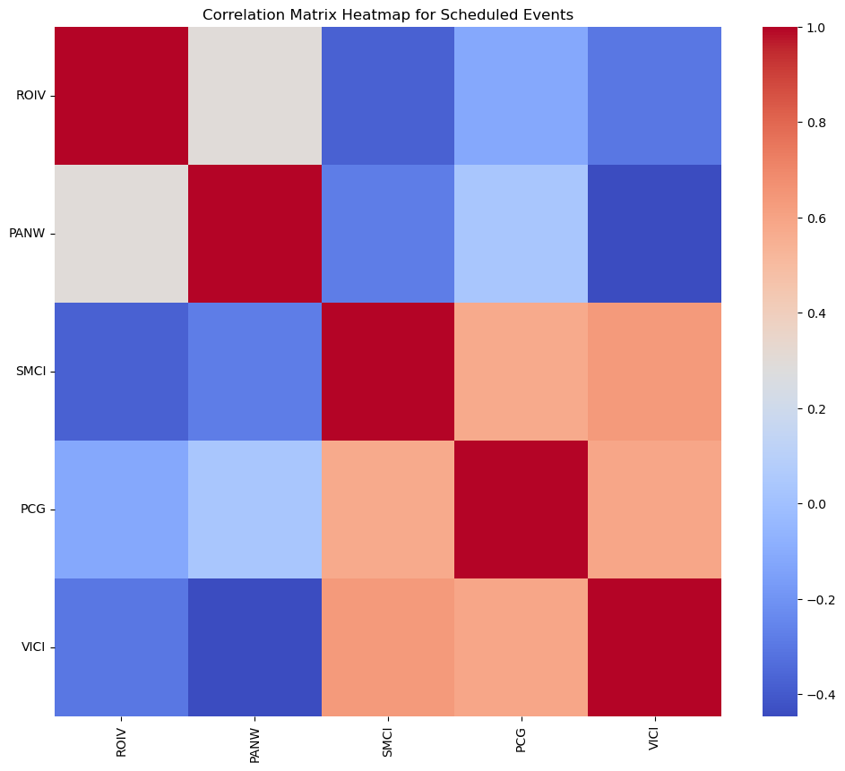

```
Full Correlation Matrix for Scheduled Events:
            ROIV_Close  PANW_Close  SMCI_Close  PCG_Close  VICI_Close
ROIV_Close    1.000000    0.295145   -0.376189  -0.114666   -0.301854
PANW_Close    0.295145    1.000000   -0.278827   0.032413   -0.446576
SMCI_Close   -0.376189   -0.278827    1.000000   0.571259    0.635941
PCG_Close    -0.114666    0.032413    0.571259   1.000000    0.591788
VICI_Close   -0.301854   -0.446576    0.635941   0.591788    1.000000
```

```python
# Call the generalized correlation function for scheduled events
scheduled_correlation_matrix = calculate_correlation(scheduled_liquid_stocks_df, close_prices_scheduled, event_type="Scheduled Events")
```

### FRED Data Extraction (Targeted for Stocks I selected)

```python
# FRED DATA EXTRACTION
fred = Fred(api_key='91ee23f35b975fbad796eab7bfe974a9')

# Get the first and last announcement dates from your cleaned dataset
first_announcement_date = one_off_liquid_stocks_df['Announced'].min()
last_announcement_date = one_off_liquid_stocks_df['Announced'].max()

# Define the extended end date (last announcement date + 100 days)
extended_end_date = last_announcement_date + pd.Timedelta(days=100)

# Fetch Fed Funds rate data from FRED for the entire date range
fed_funds_data = fred.get_series('FEDFUNDS', observation_start=first_announcement_date, observation_end=extended_end_date)

# Convert the fetched data into a DataFrame for easier handling
fed_funds_df = pd.DataFrame(fed_funds_data, columns=['Fed Funds Rate'])
fed_funds_df['Date'] = fed_funds_df.index
fed_funds_df.reset_index(drop=True, inplace=True)

# Calculate long and short position costs
fed_funds_df['Long Position Cost'] = (fed_funds_df['Fed Funds Rate'] + 1.5)/365
fed_funds_df['Short Position Cost'] = (fed_funds_df['Fed Funds Rate'] + 1.0)/365

# Display the first few rows to verify the data
print(fed_funds_df.head(n=10))
print("\n")
print(fed_funds_df.tail())  # Check last few rows to ensure data is complete for the extended period
```

```
   Fed Funds Rate       Date  Long Position Cost  Short Position Cost
0            3.08 2022-10-01            0.012548             0.011178
1            3.78 2022-11-01            0.014466             0.013096
2            4.10 2022-12-01            0.015342             0.013973
3            4.33 2023-01-01            0.015973             0.014603
4            4.57 2023-02-01            0.016630             0.015260
5            4.65 2023-03-01            0.016849             0.015479
6            4.83 2023-04-01            0.017342             0.015973
7            5.06 2023-05-01            0.017973             0.016603
8            5.08 2023-06-01            0.018027             0.016658
9            5.12 2023-07-01            0.018137             0.016767


    Fed Funds Rate       Date  Long Position Cost  Short Position Cost
19            5.33 2024-05-01            0.018712             0.017342
20            5.33 2024-06-01            0.018712             0.017342
21            5.33 2024-07-01            0.018712             0.017342
22            5.33 2024-08-01            0.018712             0.017342
23            5.13 2024-09-01            0.018164             0.016795
```

### Technical Analysis Indicators Construction

```python
# Technical Analysis Indicators Construction
import yfinance as yf
import pandas as pd
import talib  # TA-Lib for technical analysis

# Function to add customized RSI, MACD, ATR, and Bollinger Bands (BB) using TA-Lib
def add_ta_indicators(df, is_daily=False):
    # Adjust indicator time periods based on whether it's intraday or daily data
    if is_daily:
        rsi_period = 2  # Use longer periods for daily data
        macd_fast = 2
        macd_slow = 4
        macd_signal = 2
        atr_period = 2
        bb_period = 2
    else:
        rsi_period = 6  # Use shorter periods for intraday data
        macd_fast = 6
        macd_slow = 12
        macd_signal = 6
        atr_period = 12
        bb_period = 12

    df['RSI'] = talib.RSI(df['Close'], timeperiod=rsi_period)
    df['MACD'], df['MACD_Signal'], _ = talib.MACD(df['Close'], fastperiod=macd_fast, slowperiod=macd_slow, signalperiod=macd_signal)
    df['ATR'] = talib.ATR(df['High'], df['Low'], df['Close'], timeperiod=atr_period)
    df['BB_upper'], df['BB_middle'], df['BB_lower'] = talib.BBANDS(df['Close'], timeperiod=bb_period, nbdevup=2, nbdevdn=2, matype=0)

    return df

# Function to fetch intraday or daily data based on available range
def fetch_stock_data(ticker, start_date, end_date, is_daily=False):
    try:
        if not is_daily:
            # Attempt to fetch 1-hour intraday data
            stock_data = yf.download(ticker, start=start_date, end=end_date, interval='1h')
            if stock_data.empty:
                raise ValueError(f"No intraday data for {ticker}, switching to daily data.")
        else:
            # Fetch daily data
            stock_data = yf.download(ticker, start=start_date, end=end_date, interval='1d')
            print(f"Fetched daily data for {ticker}.")
    except Exception as e:
        print(e)
        # Fallback to daily data if needed
        stock_data = yf.download(ticker, start=start_date, end=end_date, interval='1d')
        print(f"\nFetched daily data for {ticker} instead.")
    return stock_data

# Iterate over each ticker and determine if it should use intraday or daily data
indicator_dfs = {}
for index, row in one_off_liquid_stocks_df.iterrows():
    ticker = row['Ticker']
    start_date = pd.to_datetime(row['Announced'])  # Announcement date
    end_date = start_date + pd.Timedelta(days=100)  # 100-day window

    # Check if the ticker requires daily data (due to the intraday limit)
    is_daily = ticker == 'AR'

    # Fetch stock data with the appropriate interval
    stock_data = fetch_stock_data(ticker, start_date, end_date, is_daily=is_daily)

    # Check if data is available
    if not stock_data.empty:
        # Add indicators to stock data, adjusting for intraday/daily
        stock_data_with_indicators = add_ta_indicators(stock_data, is_daily=is_daily)

        # Save the data with indicators
        indicator_dfs[ticker] = stock_data_with_indicators

        # Display the first few rows of indicators for each ticker
        print(f"\nTechnical indicators for {ticker}:")
        print(stock_data_with_indicators.head(n=20))
    else:
        print(f"No data found for {ticker}.")
```

```
[*********************100%%**********************]  1 of 1 completed
```

```
Technical indicators for AVTR:
                                Open       High        Low      Close  \
Datetime
2024-07-23 09:30:00-04:00  22.000000  22.209999  21.139999  21.360001
2024-07-23 10:30:00-04:00  21.360001  21.500000  21.340000  21.389999
2024-07-23 11:30:00-04:00  21.385000  21.514999  21.379999  21.455000
2024-07-23 12:30:00-04:00  21.455000  21.510000  21.410000  21.469999
2024-07-23 13:30:00-04:00  21.469999  21.469999  21.299999  21.309999
2024-07-23 14:30:00-04:00  21.315001  21.315001  21.139999  21.165001
2024-07-23 15:30:00-04:00  21.155001  21.190001  21.120001  21.160000
2024-07-24 09:30:00-04:00  22.570000  22.570000  22.030001  22.450001
2024-07-24 10:30:00-04:00  22.450001  22.695000  22.410000  22.584999
2024-07-24 11:30:00-04:00  22.590000  22.660000  22.455000  22.639999
2024-07-24 12:30:00-04:00  22.629999  22.709999  22.490000  22.590000
2024-07-24 13:30:00-04:00  22.590000  22.705000  22.490000  22.570000
2024-07-24 14:30:00-04:00  22.565001  22.584999  22.320000  22.434999
2024-07-24 15:30:00-04:00  22.430000  22.565001  22.360001  22.365000
2024-07-25 09:30:00-04:00  22.100000  22.770000  22.060101  22.629999
2024-07-25 10:30:00-04:00  22.639999  22.730000  22.379999  22.674999
2024-07-25 11:30:00-04:00  22.674999  22.969999  22.620001  22.955000
2024-07-25 12:30:00-04:00  22.950001  23.070000  22.895000  23.010000
2024-07-25 13:30:00-04:00  23.014999  23.014999  22.711000  22.809999
2024-07-25 14:30:00-04:00  22.809999  22.959999  22.639999  22.805000

                           Adj Close   Volume        RSI      MACD  \
Datetime
2024-07-23 09:30:00-04:00  21.360001  2795359        NaN       NaN
2024-07-23 10:30:00-04:00  21.389999   945806        NaN       NaN
2024-07-23 11:30:00-04:00  21.455000  1109701        NaN       NaN
2024-07-23 12:30:00-04:00  21.469999  2820658        NaN       NaN
2024-07-23 13:30:00-04:00  21.309999   770420        NaN       NaN
2024-07-23 14:30:00-04:00  21.165001  1066442        NaN       NaN
2024-07-23 15:30:00-04:00  21.160000  1888429  26.190282       NaN
2024-07-24 09:30:00-04:00  22.450001  7537419  84.247989       NaN
2024-07-24 10:30:00-04:00  22.584999  3684691  85.664081       NaN
2024-07-24 11:30:00-04:00  22.639999  2766845  86.267638       NaN
2024-07-24 12:30:00-04:00  22.590000  2085174  82.479560       NaN
2024-07-24 13:30:00-04:00  22.570000  2158120  80.776945       NaN
2024-07-24 14:30:00-04:00  22.434999  2521788  69.205528       NaN
2024-07-24 15:30:00-04:00  22.365000  5221524  63.541810       NaN
```

[output cut: 37 more lines]

```
2024-07-23 14:30:00-04:00        NaN
2024-07-23 15:30:00-04:00        NaN
2024-07-24 09:30:00-04:00        NaN
2024-07-24 10:30:00-04:00        NaN
2024-07-24 11:30:00-04:00        NaN
2024-07-24 12:30:00-04:00        NaN
2024-07-24 13:30:00-04:00  20.609952
2024-07-24 14:30:00-04:00  20.697422
2024-07-24 15:30:00-04:00  20.804714
2024-07-25 09:30:00-04:00  20.909995
2024-07-25 10:30:00-04:00  21.041458
2024-07-25 11:30:00-04:00  21.251195
2024-07-25 12:30:00-04:00  21.615721
2024-07-25 13:30:00-04:00  22.264136
2024-07-25 14:30:00-04:00  22.303277
```

```
[*********************100%%**********************]  1 of 1 completed
```

```
Technical indicators for MARA:
                                Open       High        Low      Close  \
Datetime
2024-05-03 09:30:00-04:00  17.837999  18.209999  17.469999  17.684999
2024-05-03 10:30:00-04:00  17.690001  17.799999  17.129999  17.215000
2024-05-03 11:30:00-04:00  17.219999  17.615000  17.190001  17.455000
2024-05-03 12:30:00-04:00  17.477600  17.674999  17.299999  17.469900
2024-05-03 13:30:00-04:00  17.459999  17.575001  17.320000  17.525000
2024-05-03 14:30:00-04:00  17.525000  17.584999  17.370001  17.495001
2024-05-03 15:30:00-04:00  17.495001  17.559999  17.420000  17.500000
2024-05-06 09:30:00-04:00  18.410000  19.860001  18.230000  19.780001
2024-05-06 10:30:00-04:00  19.725000  20.299999  17.520000  20.295000
2024-05-06 11:30:00-04:00  20.299999  20.900000  20.230000  20.620001
2024-05-06 12:30:00-04:00  20.620001  21.027201  20.514999  20.840000
2024-05-06 13:30:00-04:00  20.838800  20.850000  20.480000  20.580000
2024-05-06 14:30:00-04:00  20.590000  20.689899  20.309999  20.555000
2024-05-06 15:30:00-04:00  20.549999  20.760000  20.490000  20.695000
2024-05-07 09:30:00-04:00  20.090000  20.680000  20.030001  20.100000
2024-05-07 10:30:00-04:00  20.105000  20.518499  19.910000  20.135000
2024-05-07 11:30:00-04:00  20.120001  20.495001  20.070000  20.275000
2024-05-07 12:30:00-04:00  20.275000  20.278500  19.820000  19.905001
2024-05-07 13:30:00-04:00  19.905001  20.215000  19.900000  19.969900
2024-05-07 14:30:00-04:00  19.965000  20.055000  19.700001  19.905001

                           Adj Close    Volume        RSI      MACD  \
Datetime
2024-05-03 09:30:00-04:00  17.684999  16548580        NaN       NaN
2024-05-03 10:30:00-04:00  17.215000   5797519        NaN       NaN
2024-05-03 11:30:00-04:00  17.455000   3923802        NaN       NaN
2024-05-03 12:30:00-04:00  17.469900   2903120        NaN       NaN
2024-05-03 13:30:00-04:00  17.525000   2623998        NaN       NaN
2024-05-03 14:30:00-04:00  17.495001   1830869        NaN       NaN
2024-05-03 15:30:00-04:00  17.500000   2271296  38.650294       NaN
2024-05-06 09:30:00-04:00  19.780001  21990585  85.919503       NaN
2024-05-06 10:30:00-04:00  20.295000  17653613  88.352083       NaN
2024-05-06 11:30:00-04:00  20.620001  15343513  89.699677       NaN
2024-05-06 12:30:00-04:00  20.840000   9990756  90.584529       NaN
2024-05-06 13:30:00-04:00  20.580000   7666281  80.747121       NaN
2024-05-06 14:30:00-04:00  20.555000   6582275  79.747842       NaN
2024-05-06 15:30:00-04:00  20.695000   6400592  81.302772       NaN
```

[output cut: 37 more lines]

```
2024-05-03 14:30:00-04:00        NaN
2024-05-03 15:30:00-04:00        NaN
2024-05-06 09:30:00-04:00        NaN
2024-05-06 10:30:00-04:00        NaN
2024-05-06 11:30:00-04:00        NaN
2024-05-06 12:30:00-04:00        NaN
2024-05-06 13:30:00-04:00  15.756444
2024-05-06 14:30:00-04:00  15.901268
2024-05-06 15:30:00-04:00  16.242849
2024-05-07 09:30:00-04:00  16.635292
2024-05-07 10:30:00-04:00  17.109099
2024-05-07 11:30:00-04:00  17.679077
2024-05-07 12:30:00-04:00  18.415591
2024-05-07 13:30:00-04:00  19.655518
2024-05-07 14:30:00-04:00  19.696798
```

```
[*********************100%%**********************]  1 of 1 completed
[*********************100%%**********************]  1 of 1 completed
```

```
Technical indicators for KVUE:
                                Open       High        Low      Close  \
Datetime
2023-08-21 09:30:00-04:00  23.170000  23.690001  23.030001  23.219999
2023-08-21 10:30:00-04:00  23.219999  23.309999  23.000000  23.105000
2023-08-21 11:30:00-04:00  23.108200  23.160000  22.809999  23.110001
2023-08-21 12:30:00-04:00  23.115000  23.215000  23.000000  23.200001
2023-08-21 13:30:00-04:00  23.200001  23.219999  23.000000  23.035000
2023-08-21 14:30:00-04:00  23.030001  23.090000  22.910000  23.004999
2023-08-21 15:30:00-04:00  23.004999  23.030001  22.900000  22.915001
2023-08-22 09:30:00-04:00  23.240000  23.510000  23.120001  23.485001
2023-08-22 10:30:00-04:00  23.480000  23.790001  23.420000  23.650000
2023-08-22 11:30:00-04:00  23.652201  23.740000  23.490000  23.589899
2023-08-22 12:30:00-04:00  23.580000  23.790001  23.549999  23.775000
2023-08-22 13:30:00-04:00  23.775000  23.820000  23.660000  23.735001
2023-08-22 14:30:00-04:00  23.735001  23.760000  23.549999  23.705000
2023-08-22 15:30:00-04:00  23.705000  23.780001  23.639999  23.740000
2023-08-23 09:30:00-04:00  23.850000  24.049999  23.809999  23.995001
2023-08-23 10:30:00-04:00  24.000000  24.030001  23.760000  23.934999
2023-08-23 11:30:00-04:00  23.934999  24.040001  23.850000  23.885000
2023-08-23 12:30:00-04:00  23.889999  24.010000  23.850000  23.975000
2023-08-23 13:30:00-04:00  23.975000  24.010000  23.910000  23.980000
2023-08-23 14:30:00-04:00  23.975000  23.990000  23.860001  23.910000

                           Adj Close    Volume        RSI      MACD  \
Datetime
2023-08-21 09:30:00-04:00  23.219999  56821714        NaN       NaN
2023-08-21 10:30:00-04:00  23.105000  23536399        NaN       NaN
2023-08-21 11:30:00-04:00  23.110001  16240989        NaN       NaN
2023-08-21 12:30:00-04:00  23.200001  13580429        NaN       NaN
2023-08-21 13:30:00-04:00  23.035000  13730587        NaN       NaN
2023-08-21 14:30:00-04:00  23.004999  11360584        NaN       NaN
2023-08-21 15:30:00-04:00  22.915001  13579082  19.192133       NaN
2023-08-22 09:30:00-04:00  23.485001  20511423  66.072989       NaN
2023-08-22 10:30:00-04:00  23.650000  13045031  71.763385       NaN
2023-08-22 11:30:00-04:00  23.589899   7479446  66.861623       NaN
2023-08-22 12:30:00-04:00  23.775000   5764865  73.540966       NaN
2023-08-22 13:30:00-04:00  23.735001   9058206  69.888142       NaN
2023-08-22 14:30:00-04:00  23.705000  10421158  66.897447       NaN
2023-08-22 15:30:00-04:00  23.740000  13044199  68.768466       NaN
```

[output cut: 108 more lines]

```
2022-10-24  32.900000
2022-10-25  31.950001
2022-10-26  35.319998
2022-10-27  35.315002
2022-10-28  34.910002
2022-10-31  34.470001
2022-11-01  35.730001
2022-11-02  35.139997
2022-11-03  35.380003
2022-11-04  34.490002
2022-11-07  36.165001
2022-11-08  38.280001
2022-11-09  34.279999
2022-11-10  34.779999
2022-11-11  37.045002
```

### SPY Data Extraction for Hedge

```python
# Spy data extraction for hedge
import yfinance as yf
import pandas as pd

# Extract SPY data
def get_spy_data(start_date, end_date):
    spy_data = yf.download('SPY', start=start_date, end=end_date, interval='1d')
    return spy_data[['Open', 'Close']]

# Example usage based on first and last announcement dates
first_announcement_date = one_off_liquid_stocks_df['Announced'].min()
last_announcement_date = one_off_liquid_stocks_df['Announced'].max()
extended_end_date = last_announcement_date + pd.Timedelta(days=100)

# Get SPY data
spy_data = get_spy_data(first_announcement_date, extended_end_date)
print(spy_data.head())

# Allocate Portfolio
portfolio_size = 5000000
spy_allocation = portfolio_size * 0.24  # 24% allocation to SPY
aggressive_allocation = portfolio_size * 0.76  # 76% to aggressive short strategy

# SPY Shares held throughout
spy_shares = spy_allocation / spy_data.iloc[0]['Open']  # Buy SPY at the first open price

spy_data = spy_data.copy()  # Explicitly create a copy of the DataFrame

# Track SPY value over time
spy_data.loc[:, 'SPY_Value'] = spy_shares * spy_data['Close']

# Display the first few rows to verify
print(spy_data.head())
print("\n", spy_data.tail())
```

```
[*********************100%%**********************]  1 of 1 completed
```

```
                  Open       Close
Date
2022-10-17  364.010010  366.820007
2022-10-18  375.130005  371.130005
2022-10-19  368.989990  368.500000
2022-10-20  368.029999  365.410004
2022-10-21  365.119995  374.290009
                  Open       Close     SPY_Value
Date
2022-10-17  364.010010  366.820007  1.209263e+06
2022-10-18  375.130005  371.130005  1.223472e+06
2022-10-19  368.989990  368.500000  1.214802e+06
2022-10-20  368.029999  365.410004  1.204615e+06
2022-10-21  365.119995  374.290009  1.233889e+06

                   Open       Close     SPY_Value
Date
2024-10-14  581.219971  584.320007  1.926277e+06
2024-10-15  584.590027  579.780029  1.911310e+06
2024-10-16  579.780029  582.299988  1.919618e+06
2024-10-17  585.909973  582.349976  1.919782e+06
2024-10-18  584.070007  584.590027  1.927167e+06
```

## Portfolio Construction and Returns

### Trade Signal Generation, Cost Analysis, Profit/Loss Analysis

```python
# Portfolio allocation - 19% of portfolio per ticker in the aggressive short strategy

aggressive_allocation_per_ticker = aggressive_allocation / 4  # 19% allocation per ticker

# Transaction cost per share
transaction_cost_per_share = 0.01
total_net_pnl = 0
# Initialize variables for global totals
total_winning_trades = 0
total_losing_trades = 0
total_trades_all_tickers = 0
total_percentage_return = 0
total_average_return_per_trade = 0
win_rate = 0
# Function to calculate transaction costs
def calculate_transaction_costs(num_shares):
    return num_shares * transaction_cost_per_share

# Function to calculate overnight costs (Fed Funds Rate)
def calculate_short_overnight_costs(num_shares, days_held, fed_funds_rate):
    daily_cost_rate = (fed_funds_rate + 1.0) / 365  # Fed funds rate + 1% for short positions
    return num_shares * days_held * daily_cost_rate

# Function to generate entry signals based on the open price
def generate_trade_signals(df):
    df['Signal'] = 0  # Default no signal

    # Entry conditions based on the open price (only enter at the open)
    condition_1 = df['RSI'] > 70  # RSI overbought condition
    condition_2 = (df['MACD'] > df['MACD_Signal']) & (df['MACD'] > 0)  # MACD > MACD Signal > 0
    condition_3 = df['Open'] > df['BB_middle']  # Price above upper Bollinger Band

    # Generate short signals when all conditions are met at the open
    df.loc[condition_1 & condition_2 & condition_3, 'Signal'] = -1  # Short signal

    return df

# Function to generate exit signals (at the next open price or close)
def generate_exit_signals(df, entry_price):

    df['Exit_Signal'] = 0  # Default no exit signal

    # Profit exit condition: Open price < Bollinger Band lower or 20% return on trade (since it's short, we're looking for price declines)
    profit_exit_condition = (df['Open'] < df['BB_lower']) | (df['Open'] < (entry_price * 0.80))

    # Loss exit condition
    loss_exit_condition = (df['Close'] > (entry_price * 1.10)) & (df['RSI'] > 60) & (df['ATR'] > 2)

    # Set exit signals
    df.loc[profit_exit_condition, 'Exit_Signal'] = 1  # Exit for profit
    df.loc[loss_exit_condition, 'Exit_Signal'] = 2  # Exit for loss

    return df
```

```python
percentage_returns_all = []

spy_win = 1  # Since SPY is a winning trade
spy_trade = 1  # One trade for SPY

# Function to simulate P&L with costs (transaction and overnight costs)
def simulate_pnl_with_costs(df, fed_funds_df, ticker):
    winning_trades = 0
    losing_trades = 0
    entry_price = None
    pnl = 0
    total_costs = 0
    total_trades = 0
    percentage_returns = []
    trade_active = False
    num_shares = 0
    completed_trades = 0

    print(f"\nTicker: {ticker}")

    for i, row in df.iterrows():
        # Enter short position only at open prices
        if row['Signal'] == -1 and not trade_active:
            entry_price = row['Open']
            print(f"Entered at {entry_price} on {i}")

            num_shares = aggressive_allocation_per_ticker // entry_price
            trade_active = True
            total_trades += 1
            transaction_cost = calculate_transaction_costs(num_shares)
            total_costs += transaction_cost
            entry_date = row.name

        # Exit position based on open price for profit or loss
        if row['Exit_Signal'] in [1, 2] and trade_active:
            exit_price = row['Open']
            trade_active = False
            profit = num_shares * (entry_price - exit_price)

            pct_return = (profit / (num_shares * entry_price)) * 100
            percentage_returns.append(pct_return)
            percentage_returns_all.append(pct_return)

            if pct_return > 0:
                winning_trades += 1
            else:
                losing_trades += 1

            transaction_cost = calculate_transaction_costs(num_shares)
            total_costs += transaction_cost

            days_held = (row.name - entry_date).days
            if days_held == 0:
                days_held = 1

            trade_date = pd.to_datetime(i).floor('D').tz_localize(None)
            fed_funds_rate = fed_funds_df.loc[trade_date, 'Fed Funds Rate'] if trade_date in fed_funds_df.index else 0.0
            overnight_cost = calculate_short_overnight_costs(num_shares, days_held, fed_funds_rate)
            total_costs += overnight_cost
            pnl += profit

            print(f"Exited at {exit_price} on {i}, P/L: {profit}, Return: {pct_return:.2f}%, Days Held: {days_held}, Overnight Cost: {overnight_cost}, Transaction Cost: {transaction_cost}")

            completed_trades += 1

    # Compute overall metrics after processing all rows
    cumulative_return = sum(percentage_returns)
    if completed_trades > 0:
        win_rate = (winning_trades / (winning_trades + losing_trades)) * 100
        avg_return_per_trade = cumulative_return / completed_trades
    else:
        win_rate = 0
        avg_return_per_trade = 0

    # Print summary of key metrics
    print(f"\n--- Summary for {ticker} ---")
    print(f"Total P/L: {pnl}")
    print(f"Total Trades: {completed_trades}")
    print(f"Winning Trades: {winning_trades}")
    print(f"Losing Trades: {losing_trades}")
    print(f"Win Rate: {win_rate:.2f}%")
    print(f"Average Return per Trade: {avg_return_per_trade:.2f}%")
    print(f"Total Costs: {total_costs}")
    print(f"Cumulative Percentage Return: {cumulative_return:.2f}%")

    return pnl, cumulative_return, completed_trades, total_costs, winning_trades, losing_trades, win_rate, avg_return_per_trade
```

```python
# Function to calculate the last trade date from the aggressive strategy
def get_last_trade_date(indicator_dfs):
    last_trade_date = None

    # Iterate through all the tickers
    for ticker, df in indicator_dfs.items():
        # Generate signals for entry
        df_with_signals = generate_trade_signals(df)

        # Check if any entry signals exist
        if (df_with_signals['Signal'] == -1).any():
            # Take the first entry price from signals
            entry_price = df_with_signals.loc[df_with_signals['Signal'] == -1, 'Open'].values[0]

            # Generate exit signals based on open/close rules
            df_with_signals = generate_exit_signals(df_with_signals, entry_price)

            # Check the last date when an exit signal was generated
            last_exit_date = df_with_signals[df_with_signals['Exit_Signal'] != 0].index.max()

            # Ensure the last_exit_date is timezone-naive
            last_exit_date = last_exit_date.tz_localize(None)

            # If there's no existing last_trade_date, or the current ticker's exit is later, update the last_trade_date
            if last_trade_date is None or last_exit_date > last_trade_date:
                last_trade_date = last_exit_date

    return last_trade_date

# Example usage:
last_trade_date = get_last_trade_date(indicator_dfs)
print(f"Last Trade Date: {last_trade_date}")
```

```
Last Trade Date: 2024-10-16 09:30:00
```

```python
# Spy Returns
# Normalize the last_trade_date to remove any time component
last_trade_date_naive = last_trade_date.normalize()

# Ensure both SPY data and Fed Funds data have timezone-naive datetime indexes
spy_data.index = spy_data.index.tz_localize(None)

# Convert 'Date' column in fed_funds_df to datetime and set it as index
fed_funds_df['Date'] = pd.to_datetime(fed_funds_df['Date'])  # Ensure 'Date' is in datetime format
fed_funds_df.set_index('Date', inplace=True)  # Set 'Date' as the index
fed_funds_df.index = fed_funds_df.index.tz_localize(None)  # Make the index timezone-naive

# Forward-fill the Fed Funds Rate data to ensure there is no missing data for any date
fed_funds_df.ffill(inplace=True)

# Function to calculate SPY profit/loss based on the last trade date with transaction and overnight costs
def calculate_spy_pnl(spy_data, last_trade_date, spy_shares, fed_funds_df):
    # Sell SPY at the close price on the last trade date
    spy_sell_price = spy_data.loc[last_trade_date, 'Close']

    # Calculate SPY profit
    spy_pnl = spy_shares * (spy_sell_price - spy_data.iloc[0]['Open'])

    # Calculate percentage return for SPY
    spy_pct_return = ((spy_sell_price - spy_data.iloc[0]['Open']) / spy_data.iloc[0]['Open']) * 100

    # Transaction cost for SPY (buy + sell)
    spy_transaction_cost = spy_shares * 0.01 * 2  # Buy and sell cost

    # Accumulate overnight costs for long SPY position (Fed Funds Rate + 1.5%)
    total_overnight_cost = 0
    for date in pd.date_range(spy_data.index[0], last_trade_date):
        # Align with Fed Funds data (accessing the index, not as a column)
        if date in fed_funds_df.index:
            fed_funds_rate = fed_funds_df.loc[date, 'Fed Funds Rate']
        else:
            fed_funds_rate = fed_funds_df['Fed Funds Rate'].iloc[-1]  # Use last available value

        daily_cost_rate = (fed_funds_rate + 1.5) / 365  # Long position cost (Fed Funds Rate + 1.5%)
        total_overnight_cost += spy_shares * daily_cost_rate

    # Subtract total costs (transaction + overnight) from the profit
    total_costs = spy_transaction_cost + total_overnight_cost
    net_spy_pnl = spy_pnl - total_costs

    return net_spy_pnl, spy_pct_return, spy_transaction_cost, total_overnight_cost

# Calculate SPY profit/loss
spy_pnl, spy_pct_return, spy_transaction_cost, total_overnight_cost = calculate_spy_pnl(spy_data, last_trade_date_naive, spy_shares, fed_funds_df)

spy_net_pnl = spy_pnl - spy_transaction_cost - total_overnight_cost
# Print SPY P/L, transaction cost, overnight cost, and returns
print(f"SPY Profit/Loss: {spy_pnl:.2f}")
print(f"SPY Percentage Return: {spy_pct_return:.2f}%")
print(f"SPY Transaction Cost: {spy_transaction_cost:.2f}")
print(f"SPY Total Overnight Cost: {total_overnight_cost:.2f}")
print(f"SPY Net Profit/Loss after Costs: {(spy_pnl - spy_transaction_cost - total_overnight_cost):.2f}")
```

```
SPY Profit/Loss: 675797.12
SPY Percentage Return: 59.97%
SPY Transaction Cost: 65.93
SPY Total Overnight Cost: 43754.45
SPY Net Profit/Loss after Costs: 631976.74
```

```python
# Adding the SPY hedge trade
def include_spy_in_totals(spy_pct_return, spy_net_pnl):
    global total_winning_trades, total_trades_all_tickers, total_percentage_return, total_net_pnl

    # Since SPY was a winning trade, we add it as 1 winning trade and 1 total trade
    total_winning_trades += spy_win
    total_trades_all_tickers += spy_trade
    total_percentage_return += spy_pct_return
    total_net_pnl += spy_net_pnl

# Loop over each ticker in your data
for ticker, df in indicator_dfs.items():
    df_with_signals = generate_trade_signals(df)

    if (df_with_signals['Signal'] == -1).any():
        entry_price = df_with_signals.loc[df_with_signals['Signal'] == -1, 'Open'].values[0]
        df_with_signals = generate_exit_signals(df_with_signals, entry_price)
        total_pnl, cumulative_return, total_trades, total_costs, wins, losses, win_rate, avg_return_per_trade = simulate_pnl_with_costs(df_with_signals, fed_funds_df, ticker)
        total_net_pnl += (total_pnl - total_costs)
        total_winning_trades += wins
        total_losing_trades += losses
        total_trades_all_tickers += total_trades
        total_percentage_return += cumulative_return

# Now include the SPY hedge returns
include_spy_in_totals(spy_pct_return, spy_net_pnl)

# Final calculations with SPY hedge
overall_win_rate = (total_winning_trades / total_trades_all_tickers) * 100 if total_trades_all_tickers > 0 else 0
overall_avg_return_per_trade = total_percentage_return / total_trades_all_tickers if total_trades_all_tickers > 0 else 0
```

```
Ticker: AVTR
Entered at 24.110000610351562 on 2024-07-26 09:30:00-04:00
Exited at 24.969999313354492 on 2024-09-04 09:30:00-04:00, P/L: -33885.668895721436, Return: -3.57%, Days Held: 40, Overnight Cost: 4318.027397260274, Transaction Cost: 394.02
Entered at 25.364999771118164 on 2024-09-05 14:30:00-04:00
Exited at 26.809999465942383 on 2024-09-17 14:30:00-04:00, P/L: -54119.573570251465, Return: -5.70%, Days Held: 12, Overnight Cost: 1231.331506849315, Transaction Cost: 374.53000000000003
Entered at 27.100000381469727 on 2024-09-18 13:30:00-04:00
Exited at 25.170000076293945 on 2024-10-02 09:30:00-04:00, P/L: 67656.16069793701, Return: 7.12%, Days Held: 13, Overnight Cost: 1248.5342465753424, Transaction Cost: 350.55
Entered at 24.700000762939453 on 2024-10-14 09:30:00-04:00
Exited at 24.770000457763672 on 2024-10-16 09:30:00-04:00, P/L: -2692.2582626342773, Return: -0.28%, Days Held: 2, Overnight Cost: 210.74520547945207, Transaction Cost: 384.61

--- Summary for AVTR ---
Total P/L: -23041.340030670166
Total Trades: 4
Winning Trades: 1
Losing Trades: 3
Win Rate: 25.00%
Average Return per Trade: -0.61%
Total Costs: 10016.058356164383
Cumulative Percentage Return: -2.43%

Ticker: MARA
Entered at 18.030000686645508 on 2024-05-15 10:30:00-04:00
Exited at 20.479999542236328 on 2024-05-28 14:30:00-04:00, P/L: -129087.98970222473, Return: -13.59%, Days Held: 13, Overnight Cost: 1876.5945205479452, Transaction Cost: 526.89
Entered at 20.149999618530273 on 2024-06-04 11:30:00-04:00
Exited at 18.44499969482422 on 2024-06-11 10:30:00-04:00, P/L: 80383.92640304565, Return: 8.46%, Days Held: 6, Overnight Cost: 775.0027397260274, Transaction Cost: 471.46000000000004
Entered at 20.315000534057617 on 2024-06-12 09:30:00-04:00
Exited at 19.084999084472656 on 2024-06-14 12:30:00-04:00, P/L: 57518.55778694153, Return: 6.05%, Days Held: 2, Overnight Cost: 256.23561643835615, Transaction Cost: 467.63
Entered at 19.84000015258789 on 2024-06-17 13:30:00-04:00
Exited at 19.860000610351562 on 2024-07-05 09:30:00-04:00, P/L: -957.6819190979004, Return: -0.10%, Days Held: 17, Overnight Cost: 2230.167123287671, Transaction Cost: 478.83
Entered at 19.219999313354492 on 2024-07-12 09:30:00-04:00
Exited at 20.165000915527344 on 2024-07-25 09:30:00-04:00, P/L: -46708.594190597534, Return: -4.92%, Days Held: 13, Overnight Cost: 1760.413698630137, Transaction Cost: 494.27000000000004
Entered at 21.375 on 2024-07-26 12:30:00-04:00
Exited at 13.780099868774414 on 2024-08-05 09:30:00-04:00, P/L: 337547.74143218994, Return: 35.53%, Days Held: 9, Overnight Cost: 1095.8794520547945, Transaction Cost: 444.44
Entered at 17.21500015258789 on 2024-08-08 12:30:00-04:00

--- Summary for MARA ---
Total P/L: 298695.95981025696
Total Trades: 6
Winning Trades: 3
Losing Trades: 3
```

[output cut: 101 more lines]

```
Exited at 30.5 on 2022-12-29 00:00:00, P/L: 102526.61184310913, Return: 10.79%, Days Held: 8, Overnight Cost: 608.986301369863, Transaction Cost: 277.85
Entered at 29.31999969482422 on 2023-01-09 00:00:00
Exited at 29.559999465942383 on 2023-01-13 00:00:00, P/L: -7776.232583999634, Return: -0.82%, Days Held: 4, Overnight Cost: 355.0794520547945, Transaction Cost: 324.01
Entered at 30.649999618530273 on 2023-01-17 00:00:00
Exited at 28.729999542236328 on 2023-01-19 00:00:00, P/L: 59510.402364730835, Return: 6.26%, Days Held: 2, Overnight Cost: 169.83561643835617, Transaction Cost: 309.95

--- Summary for AR ---
Total P/L: 235999.78343200684
Total Trades: 6
Winning Trades: 4
Losing Trades: 2
Win Rate: 66.67%
Average Return per Trade: 4.14%
Total Costs: 6601.973972602739
Cumulative Percentage Return: 24.84%
```

## Summary of Returns

```python
print(f"Hedge: SPY Net P/L after Costs: {spy_net_pnl:.2f}")
print(f"\nTotal Net P/L after Costs for Aggressive Bearish Strategy: {total_net_pnl - spy_net_pnl:.2f}")
print(f"\nTotal Net P/L after Costs: {total_net_pnl:.2f}")
print(f"\nTotal Net Percentage Return without compounding II: {100*(total_net_pnl)/ portfolio_size:.2f}%")
# Print the overall metrics
print(f"\nTotal Winning Trades: {total_winning_trades}")
print(f"\nTotal Losing Trades: {total_losing_trades}")
print(f"\nOverall Win Rate: {overall_win_rate:.2f}%")
print(f"\nOverall Average Return per Trade: {overall_avg_return_per_trade:.2f}%")

import numpy as np
# Convert percentage_returns_all to a numpy array
returns_array = np.array(percentage_returns_all)

print(f"\nWorst Trade: {returns_array.min():.2f}%")
print(f"\nBest Trade: {returns_array.max():.2f}%")

# Calculate the standard deviation of returns
std_dev_returns = np.std(returns_array)
risk_free_rate = 0.0  # Assumed zero for simplicity
sharpe_ratio = (overall_avg_return_per_trade - risk_free_rate) / std_dev_returns
print(f"\nSharpe Ratio: {sharpe_ratio:.2f}")
```

```
Hedge: SPY Net P/L after Costs: 631976.74

Total Net P/L after Costs for Aggressive Bearish Strategy: 662980.32

Total Net P/L after Costs: 1294957.06

Total Net Percentage Return without compounding II: 25.90%

Total Winning Trades: 13

Total Losing Trades: 10

Overall Win Rate: 56.52%

Overall Average Return per Trade: 5.84%

Worst Trade: -13.59%

Best Trade: 35.53%

Sharpe Ratio: 0.63
```

## Results Summary and Performance Evaluation

### SPY Hedge Performance:

- **Hedge Allocation**: 24% of the portfolio was allocated to SPY as a hedge.
- **Hedge Contribution**: The SPY hedge helped to offset losses during broad market uptrends, contributing $631,976.74 to the total portfolio return.
- **Net P&L from Hedge**: The long SPY position contributed 48.82% of the total portfolio return.

### Trade Metrics:

- **Win Rate**: 56.52% of trades were profitable, highlighting a balanced strategy with a slight edge in favor of winning trades.
- **Best Trade**: The most profitable trade yielded a 35.53% return.
- **Worst Trade**: The largest loss incurred was -13.59%, signaling the need for better stop-loss measures to mitigate large drawdowns.

### Risk and Volatility Management:

- **SPY Hedge Efficiency**: The 24% allocation to SPY as a hedge reduced portfolio volatility and provided consistent protection during market uptrends. It played a significant role in cushioning losses when the market moved against short positions.
- **Risk-Adjusted Returns**: While the Sharpe ratio of 0.63 demonstrates that the strategy provides positive risk-adjusted returns, refining risk management measures such as stop-losses and dynamic hedging could improve this significantly.

### Strategy Refinement Considerations:

- **Stop-Loss Improvements**: The -13.59% loss highlights the need for improved stop-loss rules. Incorporating a **dynamic ATR-based stop-loss** would minimize the impact of such large losses, however for such a simplistic strategy it could also deteriorate the effectiveness given the purposeful risk tolerance.
- **Future Enhancements**: Adding more complex strategies such as **cointegration** or **pairs trading**, as well as **predictive machine learning models**, could improve signal generation and the robustness of the strategy. These enhancements could improve the Sharpe ratio and reduce drawdowns in future iterations.

## Final Conclusion:

The momentum-based short strategy demonstrated a solid performance, with a **25.90% cumulative return** and an effective **SPY hedge** that reduced overall portfolio risk. The Sharpe ratio of 0.63 suggests a reasonable risk-adjusted return, though there is room for improvement.

To make this strategy more competitive in professional quantitative settings, enhancing **stop-loss mechanisms** and introducing more sophisticated statistical techniques such as **cointegration** or **machine learning models** for predictive analysis would further optimize results. This could potentially push the Sharpe ratio above 1.0, positioning the strategy for use in more demanding environments.

Further out-of-sample testing and backtesting on different asset classes would also be important steps toward verifying the robustness of the model and ensuring its viability in live market conditions.

For more advanced modeling techniques and quantitative research, feel free to explore my **Quantitative Research Project** on GitHub, where I delve deeper into **predictive modeling** and **machine learning algorithms**.